# 데이터 과학 – 기초 통계

시계열 예측 자동화

## 1. 대한민국 자살율

대한민국 자살율은 세계적으로 높지만 이에 대한 관심은 다른 이슈에 빠를게 잊혀져가고 있다. [자살자수 국제비교(10만명당 자살자수)](http://statkclee.github.io/politics/oecd-suicide.html)에서 OECD 통계를 바탕으로 애니메이션으로 자살율을 시각화했다.

이번에는 다양한 시계열 예측모형을 바탕으로 향후 대한민국 10만명당 자살율을 예측해보자.

## 2. 대한민국 10만명당 자살율 예측

### 2.1. 환경설정과 데이터 가져오기

[OECD 통계](https://stats.oecd.org/) 웹사이트에서 실시간으로 바로 OECD 국가별 데이터를 받아온다. 또한, [국가주요지표](http://www.index.go.kr/)에서 최근 ’14년, ’15년 정보를 가져온다.

시각화를 위한 데이터 정제과정을 함께 수행하여 가져온 데이터와 데이터 정제과정이 올바르게 수행되었는지 확인한다.

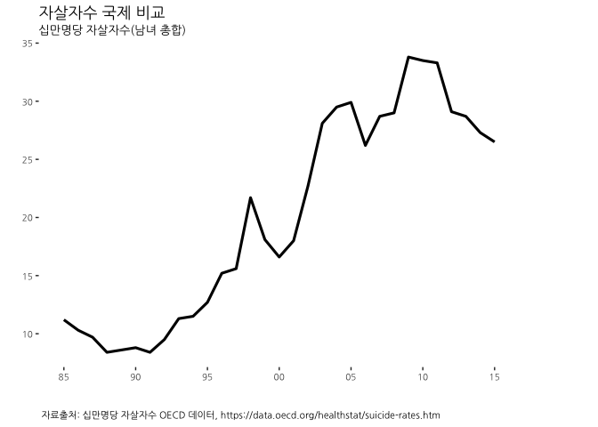

```r
# 0. 환경설정 ------------------------------------------------------------------------
#library(tidyverse)
#library(extrafont)
#library(gridExtra)
#library(astsa)
#library(fpp)
#library(ggthemes)
#library(xts)
#library(tidyquant)

# 1. 데이터 가져오기 ------------------------------------------------------------------------
# https://data.oecd.org/healthstat/suicide-rates.htm

df <- read_csv("https://stats.oecd.org/sdmx-json/data/DP_LIVE/.SUICIDE.../OECD?contentType=csv&detail=code&separator=comma&csv-lang=en")

# 2. 데이터 정제 ------------------------------------------------------------------------
# 2014년 남녀 자살자수 추가
# http://www.index.go.kr/potal/stts/idxMain/selectPoSttsIdxMainPrint.do?idx_cd=2992&board_cd=INDX_001

kor_df <- df %>%
  dplyr::filter(LOCATION =="KOR" & SUBJECT =="TOT") %>%
  dplyr::select(country=LOCATION, TIME, suicide=Value) %>%
  mutate(date = lubridate::ymd(paste0(TIME,"-01-01"))) %>% dplyr::select(-TIME) %>%
  add_row(country="KOR", suicide=27.3, date="2014-01-01") %>%
  add_row(country="KOR", suicide=26.5, date="2015-01-01")

# 3. 시각화 ------------------------------------------------------------------------
dlist <- unique(kor_df$date)

ggplot(data=kor_df, aes(x=date, y=suicide))+
  geom_line(size=1.1) +
  scale_x_date(breaks=seq(dlist[1], tail(dlist,1) + lubridate::years(1), "5 year"),
               date_labels="%y",limits=c(dlist[1], tail(dlist,1)+lubridate::years(5)))+
  theme_tufte(base_family = "NanumGothic") +
  theme(legend.position="none", plot.caption=element_text(hjust=0,size=8),plot.subtitle=element_text(face="italic"),
        axis.text=element_text(size=7.5))+
  labs(x="",y="",title="자살자수 국제 비교",
       caption="\n 자료출처: 십만명당 자살자수 OECD 데이터, https://data.oecd.org/healthstat/suicide-rates.htm",
       subtitle="십만명당 자살자수(남녀 총합)")
```

### 2.2. 자살율 예측

#### 2.2.1. 자살율 예측 사전준비

자살율 예측을 위해서 연도별 자살율을 예측하는 과정이라, `ts` 자료형으로 데이터를 변환한다.

`autoplot()` 시각화를 통해 **추세(Trend)**, **계절성(Seasonality)**, **순환(Cyclic)**이 존재하는지 확인한다.

ggAcf() 함수를 통해 자기상관이 존재하는지 시각적으로 확인하고, `Ljung-Box` 검정을 통해 자기상관이 존재하는지 통계량으로 검정한다.

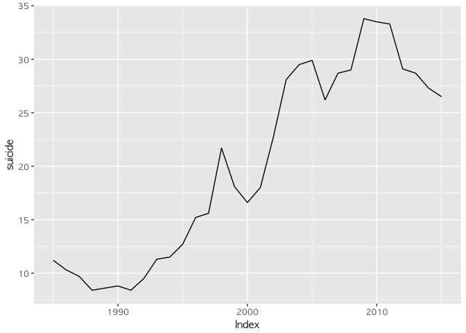

```r
# 4. 자살율 예측 ------------------------------------------------------------------------
## 4.1. 시계열 데이터 변환 --------------------------------------------------------------
# library(tidyquant)
kor_xts <- as_xts(kor_df %>% dplyr::select(-country), date_col = date)
kor_ts <- as.ts(kor_xts, start=c(1985), end=c(2015))
# kor_ts <- ts(kor_df$suicide, start=c(1985), end=c(2015), frequency=1)

## 4.2. 시계열 데이터 시각화 및 시계열 예측 적합성 --------------------------------------
autoplot(kor_xts)
```

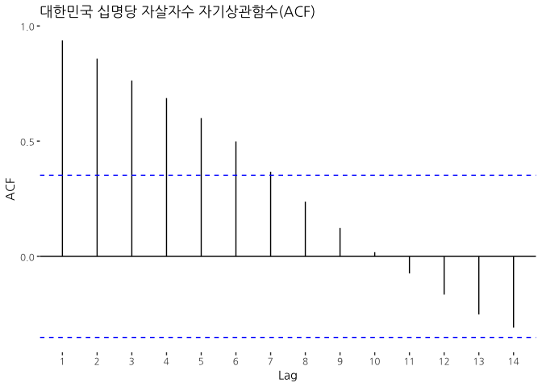

```r
ggAcf(kor_xts) +
  theme_tufte(base_family = "NanumGothic") +
  ggtitle("대한민국 십명당 자살자수 자기상관함수(ACF)")
```

```r
Box.test(kor_xts, lag = 24, fitdf = 0, type = "Lj")
```

```
    Box-Ljung test

data:  kor_xts
X-squared = 293.12, df = 24, p-value < 2.2e-16
```

#### 2.2.2. 시계열 모형 적합

자살률 시계열을 잘 설명하는 시계열 모형을 만들고 이를 바탕으로 예측모형을 생성한다. 벤치마크 모형으로 가장 최근 시계열 관측점을 다음 시점 예측값으로 사용하는 `naive` 모형부터 `ETS`, `ARIMA`, `TBATS` 모형까지 다양한다.

`ets` 함수는 1950년부터 개발된 모형으로 **innovations state space model**을 통해 오차(Error), 추세(Trend), 계절성(Seasonality)을 담아낸다. 추세와 계절성을 조합하면 지수평활(exponential smoothing)에 9가지 경우의 수가 나오고, 오차도 두가지 상태공간(state space)을 표현하여 총 18가지 모형을 적합시키게 된다.

`auto.arima()` 모형은 Hyndman-Khandakar 알고리즘을 구현한 것으로 다음 4단계를 거쳐 최적모형을 선정한다.

- 단위근 검정(Unit Test)을 통해 차분 계수를 선정
- AICc를 통해 ARIMA 모형 $p$, $q$ 모형 선정
- 최대우도추정 방법으로 모수를 추정
- 모형이 많기 때문에 단계적 검색법을 사용하여 모형탐색시간을 최소화

`tbats()` 모형은 지금까지 나온 모형에 대한 완결판으로 볼 수 있다. 한 모형으로 다양한 모형을 자동으로 담아내는 장점이 있는 반면에 강력한 컴퓨팅 파워가 뒷받침되어야 하고 예측구간이 다소 넓은 단점도 있다.

- 계절성을 잡아내기 위해 삼각함수 항을 사용
- 이질성(heterogeneity)을 잡아내는데 박스-콕스 변환을 사용
- 단기 동적 움직임(short-term dynamics)을 잡아내는데 ARMA 모형 사용
- 추세를 잡아내는데 추세항 사용
- 계절성을 잡아내는데 계절항 사용

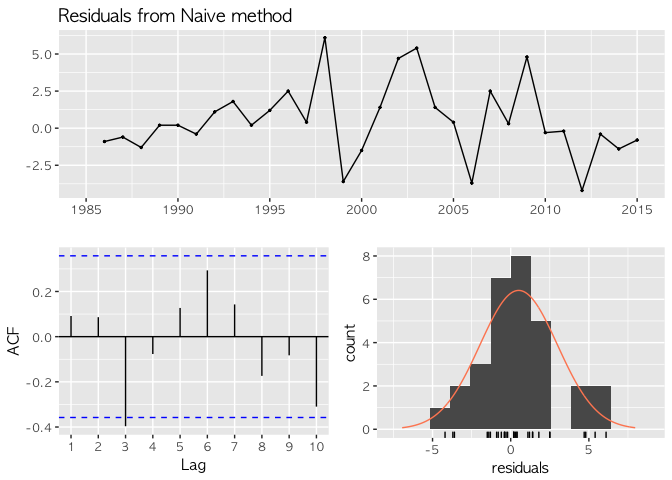

```
    Ljung-Box test

data:  residuals
Q* = 17.484, df = 10, p-value = 0.06432

Model df: 0.   Total lags used: 10
```

```r
## 4.3. 벤치마크 시계열 예측모형 --------------------------------------

kor_ts %>% naive() %>% checkresiduals()
```

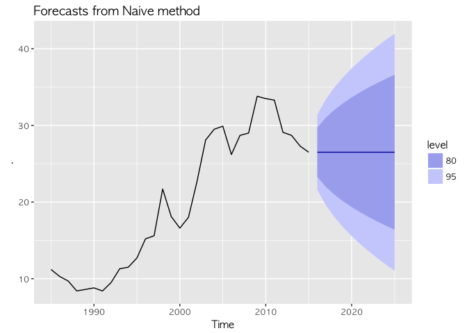

```r
kor_ts %>% naive() %>% forecast() %>% autoplot()
```

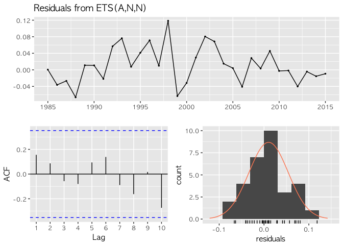

```
    Ljung-Box test

data:  residuals
Q* = 7.7468, df = 8, p-value = 0.4586

Model df: 2.   Total lags used: 10
```

```r
## 4.4. 시계열 예측모형 3종 세트 --------------------------------------

### 4.4.1. ETS 모형
kor_ts %>% ets(lambda=BoxCox.lambda(kor_xts)) %>% checkresiduals()
```

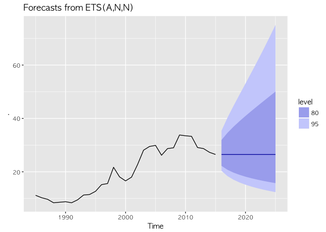

```r
kor_ts %>% ets(lambda=BoxCox.lambda(kor_xts)) %>% forecast() %>% autoplot()
```

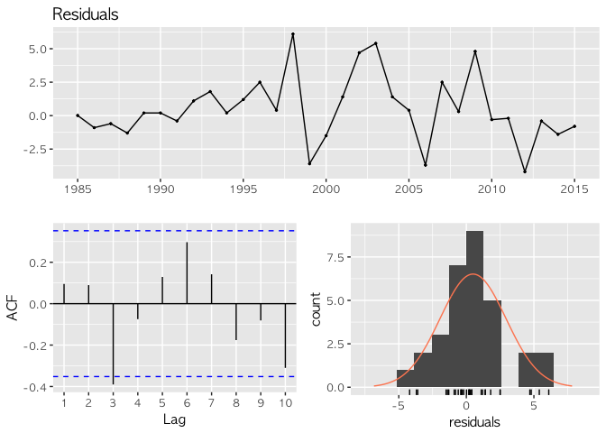

```
    Ljung-Box test

data:  residuals
Q* = 17.857, df = 10, p-value = 0.05742

Model df: 0.   Total lags used: 10
```

```r
### 4.4.2. ARIMA 모형
kor_ts %>% auto.arima() %>% checkresiduals()
```

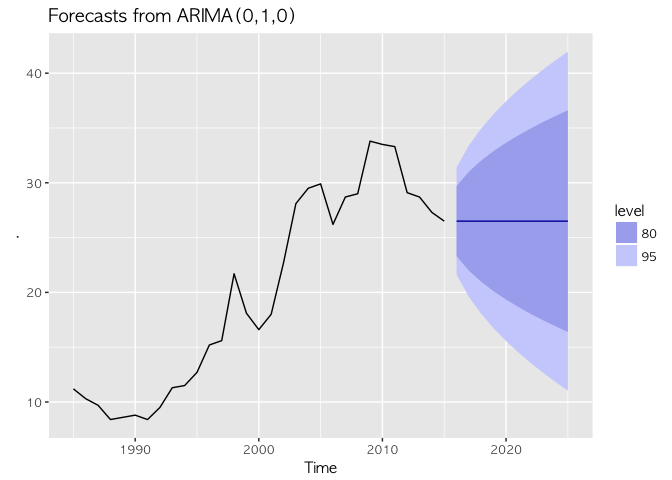

```r
kor_ts %>% auto.arima() %>% forecast() %>% autoplot()
```

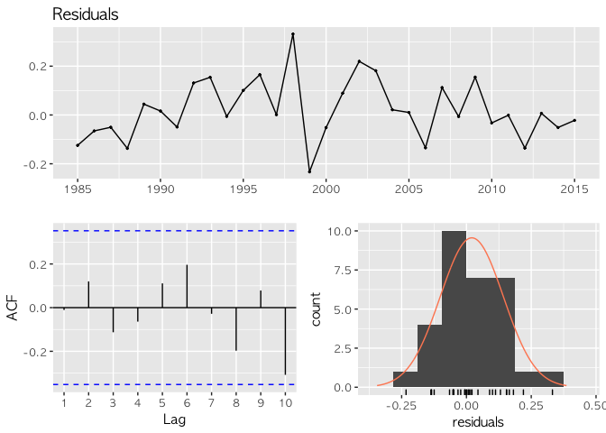

```
    Ljung-Box test

data:  residuals
Q* = 9.8574, df = 7, p-value = 0.1968

Model df: 3.   Total lags used: 10
```

```r
### 4.4.3. TBATS 모형
kor_ts %>% tbats() %>% checkresiduals()
```

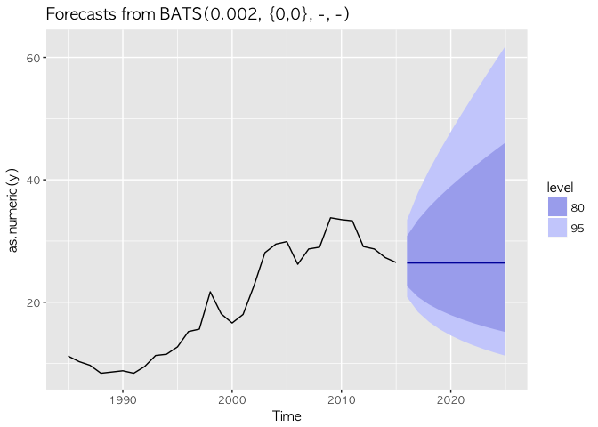

```r
kor_ts %>% tbats() %>% forecast() %>% autoplot()
```

#### 2.2.3. 자살율 예측모형 선정과 예측

실무에서 자살률 예측모형을 활용한다면 훈련 및 검증 데이터로 시계열을 나누고 이를 다양한 모형에 적합시켜 가장 예측오차가 적게 나오는 모형을 선정하고 이를 바탕으로 예측을 하는 것이 일반적이다.

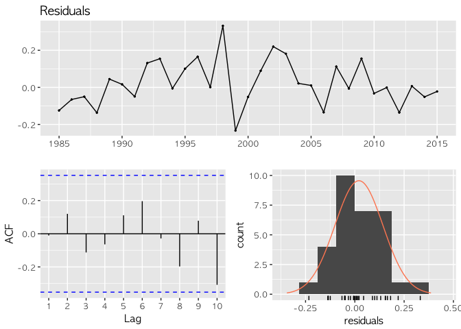

```
    Ljung-Box test

data:  residuals
Q* = 9.8574, df = 7, p-value = 0.1968

Model df: 3.   Total lags used: 10
```

```r
# 5. 예측 모형선정 ------------------------------------------------------------------------
## 5.1. 모형선정 ------------------------------------------------------------------------

kor_ts_train <- window(kor_ts, start=1985, end=2012)
kor_ts_test <- window(kor_ts, start=2013)

mod_lst <- list (
  mod_arima  = auto.arima(kor_ts_train, ic='aicc', stepwise=FALSE),
  mod_ets    = ets(kor_ts_train, ic='aicc', restrict=FALSE),
  mod_neural = nnetar(kor_ts_train, p=12, size=25),
  mod_tbats  = tbats(kor_ts_train, ic='aicc'),
  mod_bats   = bats(kor_ts_train, ic='aicc'),
  # mod_stl    = stlm(kor_ts_train, s.window=12, ic='aicc', robust=TRUE, method='ets'),
  mod_sts    = StructTS(kor_ts_train)
)

forecasts <- lapply(mod_lst, forecast, 3)
forecasts$naive <- naive(kor_ts_train, 3)

acc <- lapply(forecasts, function(f){
  accuracy(f, kor_ts_test)[2,,drop=FALSE]
})

acc <- do.call(rbind, acc)
row.names(acc) <- names(forecasts)
acc <- acc[order(acc[,'MASE']),] %>% round(2)

## 5.2. 모형적합 및 예측 ------------------------------------------------------------------------

kor_ts %>% tbats() %>% checkresiduals()
```

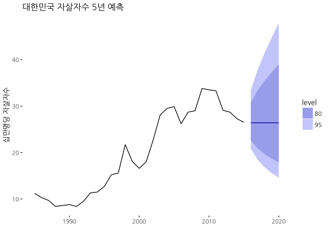

```r
kor_ts %>% tbats() %>% forecast(h=5) %>% autoplot() +
  labs(x="", y="십만명당 자살자수", title="대한민국 자살자수 5년 예측") +
  theme_tufte(base_family = "NanumGothic")
```

```r
kor_ts %>% tbats() %>% forecast(h=5) %>%
  as_tibble() %>%
  DT::datatable() %>%
  DT::formatRound(c(1:5), digits=1)
```

|  | Point Forecast | Lo 80 | Hi 80 | Lo 95 | Hi 95 |
| --- | --- | --- | --- | --- | --- |
| 2016 | 26.411524426823 | 22.6225323456824 | 30.8336666811615 | 20.8416311409516 | 33.4662595598015 |
| 2017 | 26.411524426823 | 20.8537737882549 | 33.446791143855 | 18.4012557750078 | 37.8989889283861 |
| 2018 | 26.411524426823 | 19.6427843668648 | 35.5065758908105 | 16.7919435019507 | 41.5250655944143 |
| 2019 | 26.411524426823 | 18.6917046209389 | 37.3108942222956 | 15.5641602544249 | 44.7942019027127 |
| 2020 | 26.411524426823 | 17.8986299373712 | 38.961664621757 | 14.5652511621891 | 47.8592319240509 |